# Exercice 18

Have a look at the following histogram of monthly costs (in CHF) for health care of 200 patients.

# A

The data set is stored in the file healt-care-cost.txt, available on Ilias; you can read in the one-dimensional vector using the R function scan(). Do you know a distribution that fits the data? Try to fit this distribution to the data set, for instance by using the function fitdistr() from the package MASS, which estimates parameters for the selected distribution. Then check the model fit (e.g. Q-Q plot).

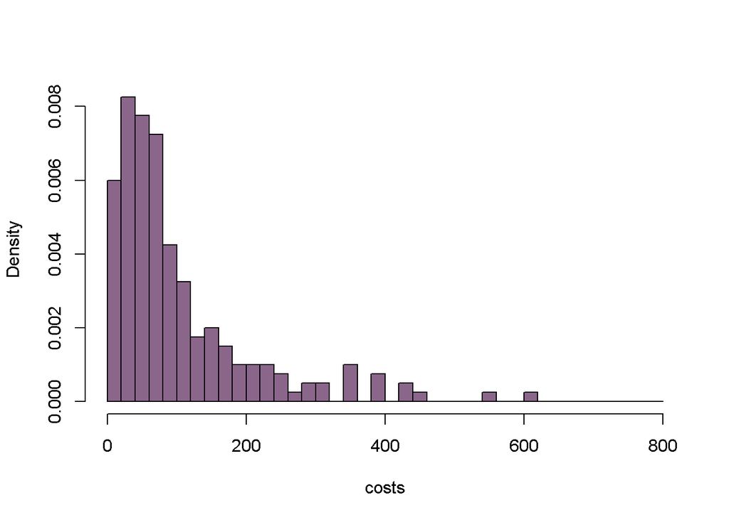

```r
costs <- scan("health-care-cost.txt")
hist(costs, freq = FALSE, breaks = seq(0, 800, by = 20), col = "plum4", main = "")
```

By looking at the histogramm we guess that we have a poisson distribution.But this can’t be because cost in CHF is a continous variable and rounded. For a possion distributin however, we would need a variable which counts and only takes integers as values. Therefore we try another distribution which allowes continues variabes. There’re two such distriburtions, the normal and exponential distribution.

But first install car (QQplot) if not already installed and load MASS (fitdistr())

```r
if(!require("car")){
  install.packages("car")
  require("car")
}
library(MASS)
```

try with the normal distribution.

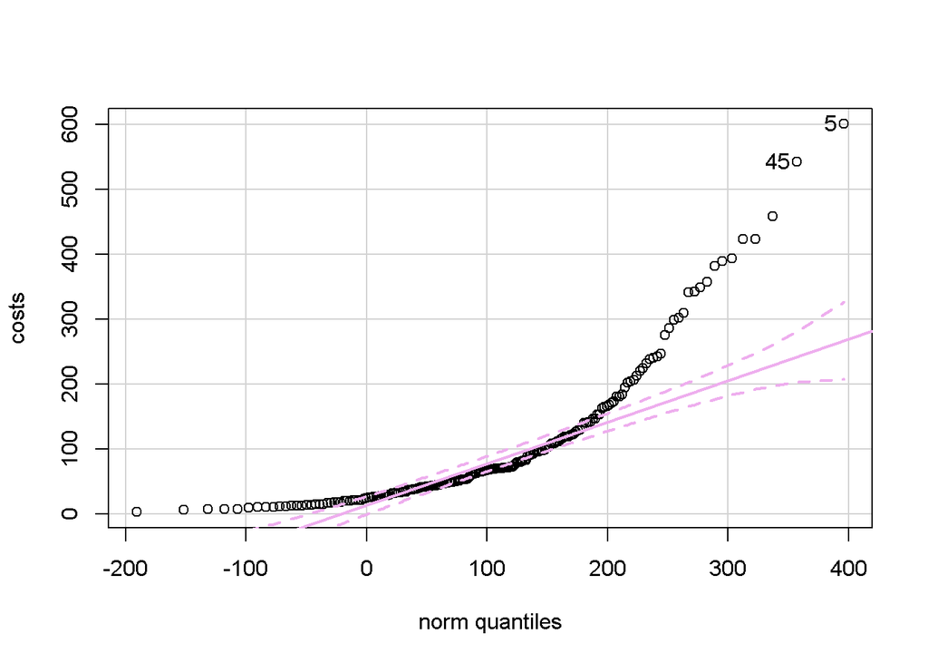

```
## [1]  5 45
```

```r
normal_distr <- fitdistr(costs, "normal")
qqPlot(costs, dist = "norm", mean = normal_distr$estimate["mean"], sd = normal_distr$estimate["sd"], col.lines="Plum2")
```

We observe that the function does not fit very well the data, so it’s probably not the right distribution. We test therefore the exponential distribution:

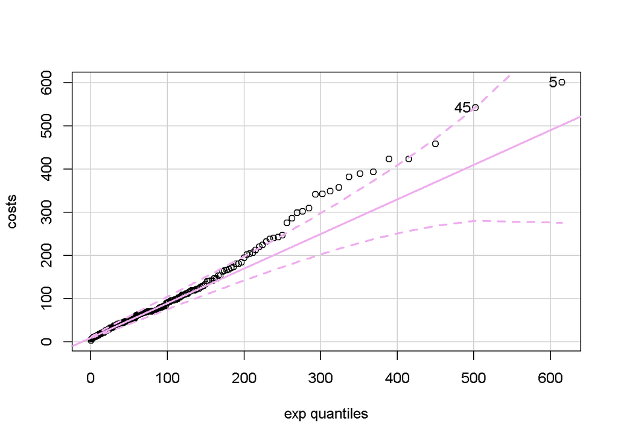

```
## [1]  5 45
```

```r
exp_distr <- fitdistr(costs, "exponential")
qqPlot(costs, dist = "exp", rate = exp_distr$estimate["rate"], col.lines="Plum2")
```

Obviously the exponential distribution does not fit well either…

# B

Perform a log-transformation on the data set. Then, draw a histogram of the transformed costs. As in task a), choose a distribution that fits the log-transformed data well, estimate its parameters and check your final model. Plot the estimated density function as a line into the histogram.

we fist do the log transformation.

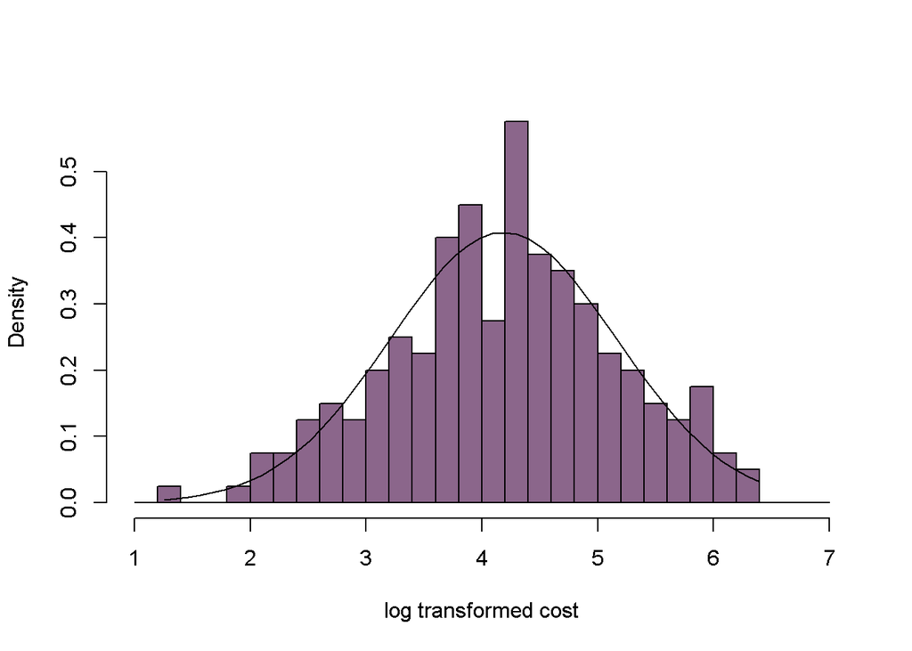

```r
log_costs <- log(costs)
hist(log_costs, freq = FALSE, breaks = seq(1, 7, by = 0.2), col = "plum4", main = "", xlab="log transformed cost")
x.val <- seq(min(log_costs), max(log_costs), length = 50)
norm_dist <- fitdistr(log_costs, "normal")
lines(x.val, dnorm(x.val, mean = norm_dist$estimate["mean"], sd = norm_dist$estimate["sd"]))
```

we see it makes highly skewed distributions less skewed. Now we try to compare it again with the normal distrbiution:

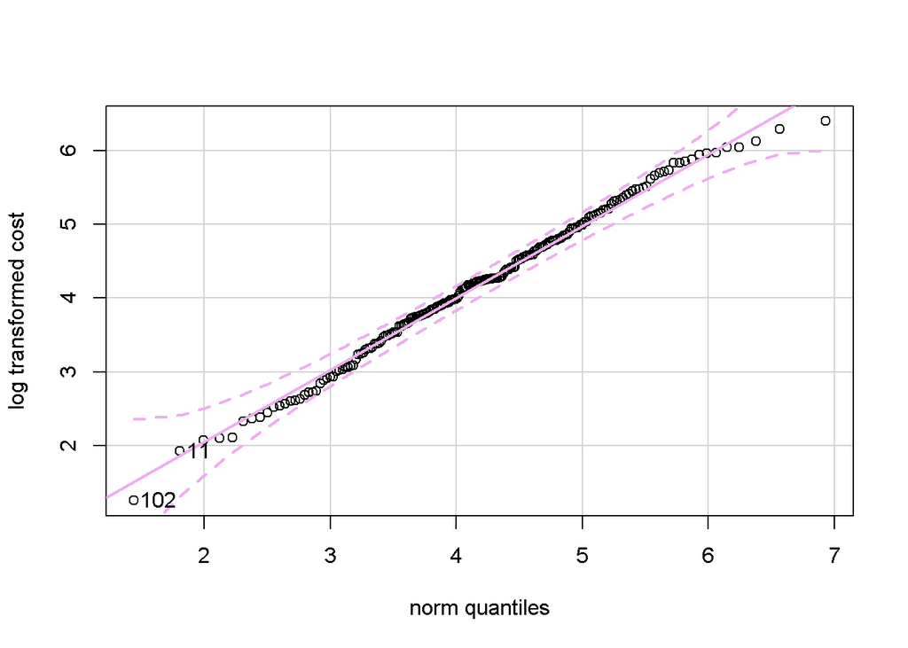

```
## [1] 102  11
```

```r
qqPlot(log_costs, dist = "norm", mean = norm_dist$estimate["mean"], sd = norm_dist$estimate["sd"], col.lines="Plum2", ylab="log transformed cost")
```

# C

Explicitely indicate the values of the parameters of the ﬁtted distribution of the log-transformed cost data.

We can read the data from the norm_dist

```r
norm_dist
```

```
##       mean          sd
##   4.18541817   0.97764830
##  (0.06913017) (0.04888241)
```

Therefore we have a normal distribution N(μ, σ) with **mean μ = 4.185** and **standard deviation σ = 0.978**.